# 02 Statistics

4th August 2025

## Lecture Outline

1. Hypothesis Testing
2. Multiple Testing Considerations

## Hypothesis Testing

## Hypothesis Testing

In biological research we often ask:

**“Is something happening?”** or **“Is nothing happening?”**

Perhaps more correctly, we are asking:

**“Would it be reasonable to conclude that there is nothing clearly happening, given the results we are seeing?”**

## Hypothesis Testing

We might be comparing outcomes among treatment groups:

- Cell proliferation in response to antibiotics in media
- mRNA abundance in two related cell types
- Allele frequencies in two populations
- Methylation levels across genomic regions

## Hypothesis Testing

How do we decide if our experimental results are “important”?

Asking if the outcomes could occur by chance alone if there really were no differences in outcomes.

- Is it normal variability?
- What would the data look like if our experiment had no effect?
- What would our data look like if there was an effect?

Every experiment is considered as a **random sample** from all possible repeated experiments.

## Sampling

### Examples

Most experiments involve measuring something:

- Discrete values e.g. read counts, number of colonies
- Continuous values e.g. *C<sub>t</sub>* values, fluorescence intensity

Every experiment is considered as a **random sample** from all possible repeated experiments.

## Sampling

### Examples

Many data collections can also be considered as experimental data sets

In the 100,000 Genomes Project a risk allele for T1D has a frequency of \(\pi = 0.07\) in European Populations.

- **Does this mean, the allele occurs in exactly 7% of Europeans?**

## Sampling

### Examples

In our *in vitro* experiment, we found that 90% of HeLa cells were lysed by exposure to our drug.

- **Does this mean that exactly 90% of HeLa cells will always be destroyed?**

## Population Parameters

- Experimentally-obtained values represent an **estimate** of the **true effect**
- More formally referred to as **population-level** parameters
- Every experiment is considered a random sample of the complete population
- Repeated experiments would give a different (but similar) estimate

All population parameters are considered to be fixed values, e.g.

- Allele frequency (\(\pi\)) in a population
- The **average difference** in mRNA levels

## Hypothesis Testing

### The Null Hypothesis

All classical statistical testing involves:

1. a **Null Hypothesis** (\(H_0\)) and
2. an **Alternative Hypothesis** (\(H_A\))

**Why do we do this?**

## Hypothesis Testing

### The Null Hypothesis

- We define \(H_0\) so that *we know what the data will look like if there is no effect*
- The alternate (\(H_A\)) includes every other possibility besides \(H_0\)

An experimental hypothesis may be

\[ H_0: \mu = 0 \quad Vs \quad H_A: \mu \neq 0 \]

Where \(\mu\) represents the **true** average difference in a value (e.g. mRNA expression levels)

## The Sample Mean

### Normally Distributed Data

For every experiment we conduct we can get two key values:

1: The sample mean (\(\bar{x}\)) estimates the population-level mean (e.g. \(\mu\))

\[ \text{For} \quad \mathbf{x} = (x_1, x_2, ..., x_n) \] \[ \bar{x} = \frac{1}{n}\sum_{i = i}^n x_i \]

This will be a different value every time we repeat the experiment. *This is an estimate of the **true** effect*

## The Sample Variance

### Normally Distributed Data

For every experiment we conduct we can get two key values:

2: The sample variance (\(s^2\)) estimates the population-level variance (\(\sigma^2\))

\[ s^2 = \frac{1}{n-1} \sum_{i = 1}^n (x_i - \bar{x})^2 \]

This will also be a different value every time we repeat the experiment.

## The Sample Mean

### A qPCR Experiment

- Comparing expression levels of *FOXP3* in T<sub>reg</sub> and T<sub>h</sub> cells (\(n = 4\) donors)
- The difference within each donor is obtained as \(\Delta \Delta C_t\) values
- \(\mathbf{x} =\) (2.1, 2.8, 2.5, 2.6)

## The Sample Mean

### A qPCR Experiment

- Comparing expression levels of *FOXP3* in T<sub>reg</sub> and T<sub>h</sub> cells (\(n = 4\) donors)
- The difference within each donor is obtained as \(\Delta \Delta C_t\) values
- \(\mathbf{x} =\) (2.1, 2.8, 2.5, 2.6)

\(H_0: \mu = 0\) Vs \(H_A: \mu \neq 0\)

where \(\mu\) is the average difference in *FOXP3* expression in the entire population

## The Sample Mean

### A qPCR Experiment

Now we can get the sample mean:

\[ \begin{aligned} \bar{x} &= \frac{1}{n}\sum_{i = i}^n x_i \\ &= \frac{1}{4}(2.1 + 2.8 + 2.5 + 2.6) \\ &= 2.5 \end{aligned} \]

This is our estimate of the **true mean** difference in expression (\(\mu\))

## The Sample Mean

### A qPCR Experiment

And the sample variance:

\[ \begin{aligned} s^2 &= \frac{1}{n - 1} \sum_{i = 1}^n (x_i - \bar{x})^2\\ & = \frac{1}{3}\sum_{i = 1}^4 (x_i - 2.5)^2\\ &= 0.0867 \end{aligned} \]

## The Sample Mean

- Every time we repeat an experiment, we obtain a different value for \(\bar{x}\)
- Would these follow any specific pattern?

\[ \mathbf{\bar{x}} = \{\bar{x}_1, \bar{x}_2, \dots, \bar{x}_m \} \]

This represents a theoretical set of repeated experiments with a different sample mean for each.

We usually just have **one** experiment (\(\bar{x}\)).

## The Sample Mean

- Every time we repeat an experiment, we obtain a different value for \(\bar{x}\)
- Would these follow any specific pattern?
- **They would be normally distributed around the true value!**

\[ \mathbf{\bar{x}} \sim \mathcal{N}(\mu, \frac{\sigma}{\sqrt{n}}) \]

where:

- \(\mu\) represents the true population mean
- \(\sigma\) represents the standard deviation in the population (probably unknown)
- Recall that the standard deviation, \(\sigma\), is the square root of the variance, \(\sigma^2\)

## The Null Hypothesis

**We know what our experimental results (\(\bar{x}\)) will look like**.

\[ \bar{x} \sim \mathcal{N}(\mu, \frac{\sigma}{\sqrt{n}}) \]

If we subtract the population mean:

\[ \bar{x} - \mu \sim \mathcal{N}(0, \frac{\sigma}{\sqrt{n}}) \]

NB: We almost always test for no effect \(H_0: \mu = 0\)

## The Null Hypothesis

- One final step gives us a \(Z\) statistic where \(Z \sim \mathcal{N}(0, 1)\)

\[ Z = \frac{\bar{x} - \mu}{\sigma / \sqrt{n}} \sim \mathcal{N}(0, 1) \]

- If \(H_0\) is true \(Z\) will come from \(\mathcal{N}(0, 1)\)
- If \(H_0\) is NOT true \(Z\) will come from some other distribution
- We compare our results (i.e. \(Z\)) to \(\mathcal{N}(0, 1)\) and see if our results are likely or unlikely
- In reality we usually don’t know \(\sigma\)

## The Null Hypothesis

- We are usually testing for an **unknown population value** (i.e. \(\mu\))
- Commonly we are testing that an average difference is zero (\(\mu = 0\))
- The alternative is that \(\mu \neq 0\)
- We use our experiment to draw conclusions about \(\mu\)

\[ H_0: \mu = 0 \quad \text{vs} \quad H_A: \mu \neq 0 \]

## The Null Hypothesis

**If \(H_0\) is true, where would we expect \(Z\) to be?**  
**If \(H_0\) is NOT true, where would we expect \(Z\) to be?**

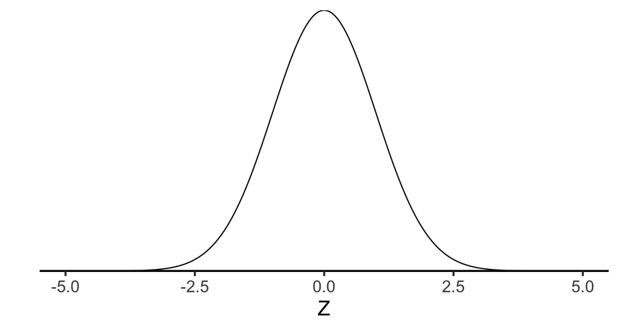

## The Null Hypothesis

**Would a value \(Z > 1\) be likely if \(H_0\) is TRUE?**

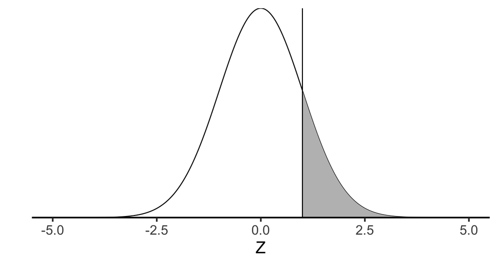

## The Null Hypothesis

**Would a value \(>2\) be likely if \(H_0\) is TRUE?**

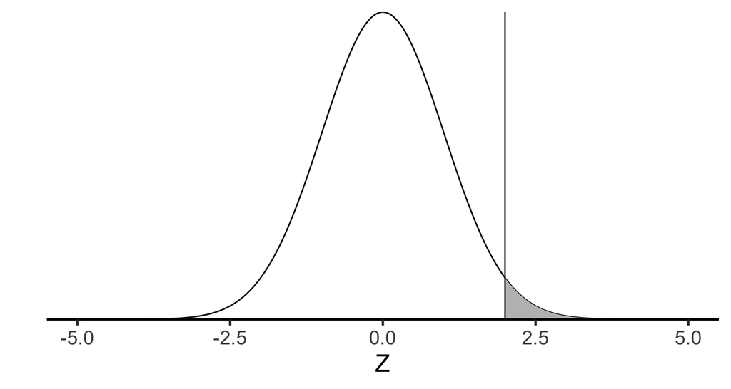

## \(p\) Values

- The area under all probability distributions adds up 1
- The area to the right of 2, is the probability of obtaining \(Z >2\)
- This is 0.023
- Thus **if \(H_0\) is true, we know the probability of obtaining a \(Z\)-statistic \(>2\)**

## \(p\) Values

**In our qPCR experiment, could the \(\Delta \Delta C_t\) values be either side of zero?**

## \(p\) Values

**In our qPCR experiment, could the \(\Delta \Delta C_t\) values be either side of zero?**

- Gene expression could go up or down after our treatment
- This means we also need to check the values for the other extreme
- This distribution is symmetric around zero:

\[p(|Z| > 2) = p(Z > 2) + P(Z < -2)\]

- Known as a *two-sided* test

**This is the most common way of determining how much evidence we have against \(H_0\)**

## \(p\) Values

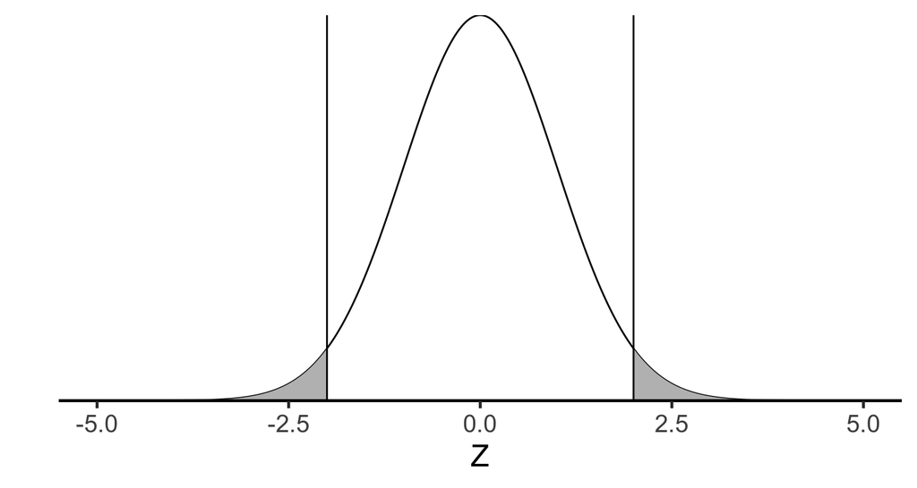

## \(p\) Values

\[ Z = \frac{\bar{x} - \mu}{\sigma / \sqrt{n}} \]

1. We first calculate \(Z\), and compare to \(\mathcal{N}(0, 1)\)
2. We obtain the probability of obtaining a \(Z\)-statistic *at least as extreme* as our value
   - If \(H_0\) is true, \(Z\) will come from \(\mathcal{N}(0, 1)\)
   - If \(H_0\) is NOT true, we have no idea where \(Z\) will be.
   - It can be anywhere \(-\infty < Z < \infty\)

## \(p\) Values

### Definition

> A \(p\) value is the probability of observing data as extreme, or more extreme than we have observed, if \(H_0\) is true.

To summarise:

1. We calculate a test statistic \(Z\) using \(\mu = 0\) and \(\sigma\)
2. Compare this to \(\mathcal{N}(0, 1)\) to find the probability (\(p\)) of observing data as extreme, or more extreme, than we observed if \(H_0\) is true
3. If \(p\) is low (e.g. \(p<0.05\)), we reject \(H_0\) as unlikely and infer \(H_A\)

## The \(t\)-test

## \(t\)-tests

In reality, we will never know the population variance (\(\sigma^2\)), just like we will never know \(\mu\)

- If we knew these values we wouldn’t need to do any experiments
- We can use our *sample variance* (\(s^2\)) to estimate \(\sigma^2\)

**Due to the uncertainty introduced by using \(s^2\) instead of \(\sigma^2\) we can no longer compare to the \(Z \sim \mathcal{N}(0, 1)\) distribution.**

## \(t\)-tests

Instead we use a \(T\)-statistic

\[ T = \frac{\bar{x} - \mu}{s / \sqrt{n}} \]

Then we compare to a \(t\)-distribution

## \(t\)-tests

### The t distribution

The \(t\)-distribution is very similar to \(\mathcal{N}(0, 1)\)

- Bell-shaped & symmetrical around zero
- Has fatter tails \(\implies\) extreme values are more likely
- The parameter *degrees of freedom* (\(\nu\)) specifies how “fat” the tails are
- As \(\nu \rightarrow 0\) the tails get fatter

## \(t\)-tests

### The t distribution

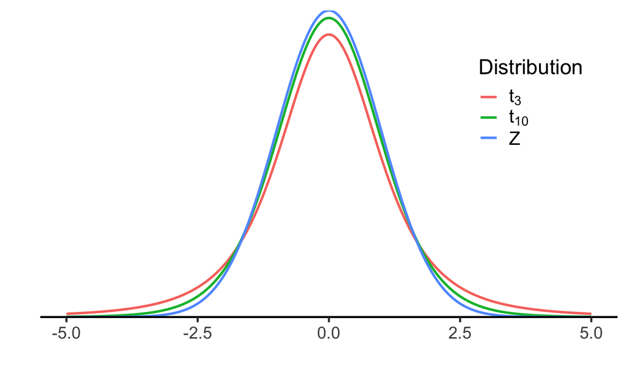

## \(t\)-tests

### Degrees Of Freedom

At their simplest:

\[ \text{df} = \nu = n - 1 \]

As \(n\) increases \(s^2 \rightarrow \sigma^2\) and \(\implies t_{\nu} \rightarrow Z\)

## \(t\)-tests

### qPCR Data

For our qPCR data, testing \(\mu = 0\):

\[ \begin{aligned} T &= \frac{\bar{x} - \mu}{s / \sqrt{n}} \\ &= \frac{2.5 - 0}{0.294392 / \sqrt{4}} \\ &= 16.984 \end{aligned} \]

## \(t\)-tests

### qPCR Data

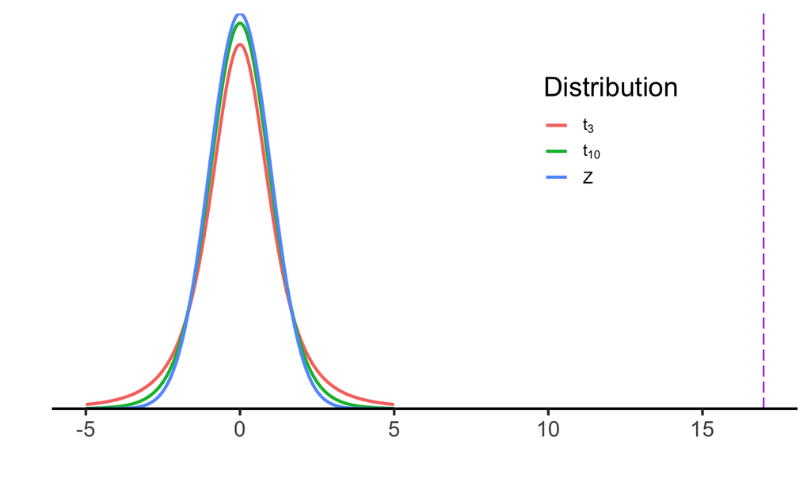

## \(t\)-tests

### qPCR Data

- Our degrees of freedom here are \(\nu = 3\)
- By comparing to \(t_3\) we get

\[p = 0.00044\]

- Thus, the probability of observing data as (or more) extreme as this is very low if \(H_0\) was true (1 in ~2300 experiments).
- We reject \(H_0\) and infer that our alternative \(H_A\) is more likely

## Hypothesis Testing

### Summary

1. Define \(H_0\) and \(H_A\)
2. Calculate sample mean (\(\bar{x}\)) and variance (\(s^2\))
3. Calculate \(T\)-statistic and degrees of freedom (\(\nu\))
4. Compare to \(t_{\nu}\) and obtain probability of observing \(\bar{x}\) if \(H_0\) is true
5. Fail to reject or reject \(H_0\) if \(p < 0.05\) (or some other value)

## Hypothesis Testing

### Summary

1. Define \(H_0\) and \(H_A\)
2. Calculate sample mean (\(\bar{x}\)) and variance (\(s^2\))
3. Calculate \(T\)-statistic and degrees of freedom (\(\nu\))
4. Compare to \(t_{\nu}\) and obtain probability of observing \(\bar{x}\) if \(H_0\) is true
5. Fail to reject or reject \(H_0\) if \(p < 0.05\) (or some other value)
- This applies to most situations
- Assumes errors (deviations of our data around the mean) are normally distributed

## Two Sample \(t\)-tests

In the above we had the \(\Delta \Delta C_t\) values within each donor.

**What if we just had 4 values from each cell-type from different donors?**

- We would be interested in the difference between the two means (\(\mu_A\) and \(\mu_B\))
- We could use a two sample \(t\)-test to compare \(\bar{x}_A\) and \(\bar{x}_B\)
- The principle is the same, calculations are different

## Two Sample \(t\)-tests

For \(H_0: \mu_A = \mu_B\) Vs \(H_A: \mu_A \neq \mu_B\)

1. Calculate the two sample means: \(\bar{x}_A\) and \(\bar{x}_B\)
2. Calculate the two sample variances \(s_A^2\) and \(s_B^2\)
3. Calculate the pooled denominator: \(\text{SE}_{\bar{x}_A - \bar{x}_B}\)
   - Formula varies for equal/unequal variances
4. Calculate the degrees of freedom
   - Formula varies for equal/unequal variances

## Two Sample \(t\)-tests

\[ T = \frac{\bar{x}_A - \bar{x}_B}{\text{SE}_{\bar{x}_A - \bar{x}_B}} \]

If \(H_0\) is true then

\[ T \sim t_{\nu} \]

1. We compare our test-statistic to this distribution
2. Are we likely to see this value (or more extreme) under \(H_0\)?
3. Fail to reject or Reject \(H_0\)

## Hypothesis Testing For Non-Normal Data

## What if our data is not Normally Distributed

**When would data not be Normally Distributed?**

- Counts: These are discrete whilst normal data is continuous
- Proportions: These are bound at 0 & 1, i.e. \(0 < \pi < 1\)
- Data generated by Exponential, Uniform, Binomial etc. processes

Two useful tests:

- Wilcoxon Rank-Sum Test
- Fisher’s Exact Test

## Wilcoxon Rank-Sum Test

\(H_0: \mu_A = \mu_B\) Vs \(H_A: \mu_A \neq \mu_B\)

- Used for any two measurement groups which are not Normally Distributed.
- Assigns each measurement a rank
- Compares ranks between groups
- Determines probability of observing differences in ranks
- Also known as the Mann-Whitney Test
- Requires higher sample sizes than \(t\)-tests

## Fisher’s Exact Test

- Used for \(2 \times 2\) tables (or \(m \times n\)) with counts and categories
  - Are relative proportions of one variable different depending on the value of the other variable?
- Analogous to a Chi-squared (\(\chi^2\)) test but more robust to small values
- Commonly used to test for enrichment of an event within one group above another group (GO terms; TF motifs; SNP Frequencies)

## Fisher’s Exact Test

An example table

|  | A | B |
| --- | --- | --- |
| **Upper Lakes** | 12 | 12 |
| **Lower Plains** | 20 | 4 |

\(H_0:\) **No association** between allele frequencies and location  
\(H_A:\) There **is an association** between between allele frequencies and location

## Fisher’s Exact Test

- We find the probability of obtaining tables with more extreme distributions, holding row and column totals fixed
  - Sum the probabilities of each table more extreme than the observed pattern (in both directions)

```
## Reject null hypothesis of no association between
## allele frequencies and loctaion
```

```
## P-value =  0.0305
```

## Error Types and Multiple Hypothesis Testing

## Evidence to Reject \(H_0\)

> A \(p\) value is the probability of observing data as (or more) extreme if \(H_0\) is true.

We commonly reject \(H_0\) if \(p < 0.05\)

**How often would we incorrectly reject \(H_0\)?**

## Evidence to Reject \(H_0\)

> A \(p\) value is the probability of observing data as (or more) extreme if \(H_0\) is true.

We commonly reject \(H_0\) if \(p < 0.05\)

**How often would we incorrectly reject \(H_0\)?**

About 1 in 20 times, we will see \(p < 0.05\) if \(H_0\) is true

## Error Types

- Type I errors are when we reject \(H_0\) but \(H_0\) is true
- Type II errors are when we fail to reject \(H_0\) when \(H_0\) is false

|  | \(H_0\) `TRUE` | \(H_0\) `FALSE` |
| --- | --- | --- |
| Reject \(H_0\) | Type I Error | \(\checkmark\) |
| Don’t Reject \(H_0\) | \(\checkmark\) | Type II Error |

**What are the consequences of each type of error?**

## Error Types

**What are the consequences of each type of error?**

Type I: Waste $$$ chasing dead ends
Type II: We miss a key discovery

- In research, we usually try to minimise Type I Errors
- Increasing sample-size reduces Type II Errors

## Family Wise Error Rates

1. Imagine we are examining every human gene (\(m=\) 25,000) for differential expression using RNASeq
2. Imagine there are 1000 genes which are truly DE

**How many times would we incorrectly reject \(H_0\) using \(p < 0.05\)**

## Family Wise Error Rates

1. Imagine we are examining every gene (\(m=\) 25,000) for differential expression using RNASeq
2. Imagine there are 1000 genes which are truly DE

**How many times would we incorrectly reject \(H_0\) using \(p < 0.05\)**

We effectively have 25,000 tests, with 24,000 times \(H_0\) is true

\(\frac{25000 - 1000}{20} = 1200\) times

**Could this lead to any research dead-ends?**

## Family Wise Error Rates

This is an example of the Family-Wise Error Rate (i.e. Experiment-Wise Error Rate)

### Definition

> The Family-Wise Error Rate (FWER) is the probability of making one or more false rejections of \(H_0\)

In our example, the FWER \(\approx 1\)

## Family Wise Error Rates

What about if we lowered the rejection value to \(\alpha = 0.001\)?

We would incorrectly reject \(H_0\) once in every 1,000 times

\(\frac{25000 - 1000}{1000} = 24\) times

The FWER is still \(\approx 1\)

## The Bonferroni Adjusment

- If we set the rejection value to \(\alpha* = \frac{\alpha}{m}\) we control the FWER at the level \(\alpha\)
- To ensure that \(p\)(one or more Type I errors) = 0.05 in our example:  
  \(\implies\) Reject \(H_0\) if \(p < \frac{0.05}{25000}\)

**What are the consequences of this?**

## The Bonferroni Adjusment

- If we set the rejection value to \(\alpha* = \frac{\alpha}{m}\) we control the FWER at the level \(\alpha\)
- To ensure that \(p\)(one or more Type I errors) = 0.05 in our example:  
  \(\implies\) Reject \(H_0\) if \(p < \frac{0.05}{25000}\)

**What are the consequences of this?**

- Large increase in Type II Errors
- BUT what we find we are very confident about \(\implies\) we don’t waste time and money on dead ends!

## The False Discovery Rate

- An alternative is to allow a small number of Type I Errors in our results \(\implies\) we have a False Discovery Rate (FDR)
- Instead of controlling the FWER at \(\alpha = 0.05\), if we control the FDR at \(\alpha = 0.05\) we allow up to 5% of our list to be Type I Errors

Most common procedure is the Benjamini-Hochberg

**What advantage would this offer?**

## The False Discovery Rate

- An alternative is to allow a small number of Type I Errors in our results \(\implies\) we have a False Discovery Rate (FDR)
- Instead of controlling the FWER at \(\alpha = 0.05\), if we control the FDR at \(\alpha = 0.05\) we allow up to 5% of our list to be Type I Errors

Most common procedure is the Benjamini-Hochberg

**What advantage would this offer?**

- Lower Type II Errors
- 5% chance we chase a dead end

## The False Discovery Rate

For those interested, the BH procedure for \(m\) tests is (not-examinable)

1. Arrange \(p\)-values in ascending order \(p_{(1)}, p_{(2)}, ..., p_{(m)}\)
2. Find the largest number \(k\) such that \(p_{(k)} \leq \frac{k}{m}\alpha\)
3. Reject \(H_0\) for all \(H_{(i)}\) where \(i \leq k\)

## The False Discovery Rate

Controlling the FDR at \(\alpha = 0.05\)

| Rank | Pvalue | BH_Pvalue | Reject_null |
| --- | --- | --- | --- |
| 1 | 0.0001 | 0.005 | 1 |
| 2 | 0.0008 | 0.010 | 1 |
| 3 | 0.0021 | 0.015 | 1 |
| 4 | 0.0234 | 0.020 | 0 |
| 5 | 0.0293 | 0.025 | 0 |
| 6 | 0.0500 | 0.030 | 0 |
| 7 | 0.3354 | 0.035 | 0 |
| 8 | 0.5211 | 0.040 | 0 |
| 9 | 0.9123 | 0.045 | 0 |
| 10 | 1.0000 | 0.050 | 0 |